# Reproducible Research Project 2: Storm Data Analysis

All the documents and code used in this project can be found at [this](https://github.com/muntasir2165/datasciencecoursera) Github repository. If the link does not work, please copy and paste the following url in your browser: https://github.com/muntasir2165/datasciencecoursera

# Data Processing

Please note that, unless stated otherwise, all R codes in the Data Processing section of this report are not actually evaluated when generating the Rmd file to save time from the lengthy processing that is required

Read in the database file into R

```r
fileName <- "repdata-data-StormData.csv.bz2"
data <- read.csv(fileName)
```

Create a new dataframe with the columns EVTYPE, FATALITIES, INJURIES, PROPDMG, PROPDMGEXP, CROPDMGEXP and CROPDMG from data

```r
data1 <- data.frame(data$EVTYPE, data$FATALITIES, data$INJURIES,
                    data$PROPDMG, data$PROPDMGEXP, data$CROPDMG, data$CROPDMGEXP)
```

Re-name the columns in the data1 data frame

```r
names(data1) <- tolower(c("EVTYPE", "FATALITIES", "INJURIES", "PROPDMG","PROPDMGEXP", "CROPDMG", "CROPDMGEXP"))
```

Turn the elements in the evtype, propdmgexp and cropdmgexp columns from factor into character

```r
data1[,1] <- as.character(data1$evtype)
data1[,5] <- as.character(data1$propdmgexp)
data1[,7] <- as.character(data1$cropdmgexp)
```

Please note that we will ignore the multipliers for property damage (PROPDMGEXP) and cropdamage (CROPDMGEXP) unless they are one of h/H (hundred), k/K (thousand), m/M (million) or b/B (billion).

There are two reasons for doing so. 1. We could not determime the meaning of the other values (such as, “0”, “1”, “2” etc.) in the PROPDMGEXP and CROPDMGEXP columns. 2. Including multipliers other than h, k, m or b in our analysis drastically increases our processing time which we are unable to afford with our computer's limited processing power and the project deadline.

Therefore, please be advised that our analysis and result interpretation that follows may not be precise or entirely correct

28 weather types considered (please not that the following weather condition listing is not exhaustive). Other unrecognized weather conditions are considered under “other”

```r
weather <- c("rain", "storm", "sun", "cloud", "hot", "cold",
             "dry", "wet", "windy", "hurricane", "typhoon",
             "sand storms", "snow storms", "tornado", "humid",
             "fog", "snow", "thundersnow", "hail", "sleet",
             "drought", "wildfire", "blizzard", "avalanche",
             "mist", "freez", "dust", "flood", "other")
```

Create a new data frame - dataSummary - to record the aggregate results of weather incident counts, fatalities, injuries, property damage, crop damage and total damage for each of the above weather conditions.

```r
incidentTotal <- vector(mode="numeric", length=length(weather))
fatalitiesTotal <-vector(mode="numeric", length=length(weather))
injuriesTotal <-vector(mode="numeric", length=length(weather))
propDmgTotal <-vector(mode="numeric", length=length(weather))
cropDmgTotal <-vector(mode="numeric", length=length(weather))
damageTotal <-vector(mode="numeric", length=length(weather))
dataSummary <- data.frame(weather, incidentTotal,
                          fatalitiesTotal, injuriesTotal,
                          propDmgTotal, cropDmgTotal, damageTotal)
```

Function to determine the multiplier's numerical value from the propdmgexp and cropdmgexp columns in the data1 dataframe

```r
multiplier <- function(letter) {
        #Return the multiplier letter's numerical value
        #If the multiplier is not one of h/H, k/K, m/M, and b/B,
        #the function returns 1
        multiplier <- 1

        if (grepl('h', tolower(letter))) multiplier <- 100
        else if (grepl('k', tolower(letter))) multiplier <- 1000
        else if (grepl('m', tolower(letter))) multiplier <- 1000000
        else if (grepl('b', tolower(letter))) multiplier <- 1000000000

        multiplier
}
```

Populate the dataSummary data frame with the aggregate results for each of the categories - fatalities, injuries, property damage, crop damage and total damage - for each of the 29 weather conditions.

The major simplifying assumption in our analysis is to ignore the rows in data1 where:

- propdmgexp is not one of h/H, k/K, m/M, and b/B
- cropdmgexp is not one of h/H, k/K, m/M, and b/B

```r
for (row in seq(data1$evtype)) {
        instance <- tolower(data1$evtype[row])
        propMultiplier <- multiplier(data1$propdmgexp[row])
        cropMultiplier <- multiplier(data1$cropdmgexp[row])
        #print(row)
        if (propMultiplier== 1 || cropMultiplier==1) {
                next
        }
        iteration <- 0
        for (index in seq(dataSummary$weather)) {
                condition <- dataSummary$weather[index]
                iteration <- iteration + 1
                found = grepl(condition, instance)
                if (found) {
                        data1$evtype[row] = condition
                        dataSummary$incidentTotal[index] = dataSummary$incidentTotal[index] + 1
                        dataSummary$fatalitiesTotal[index] = dataSummary$fatalitiesTotal[index] + data1$fatalities[row]
                        dataSummary$injuriesTotal[index] = dataSummary$injuriesTotal[index] + data1$injuries[row]
                        dataSummary$propDmgTotal[index] = dataSummary$propDmgTotal[index] + (data1$propdmg[row] * propMultiplier)
                        dataSummary$cropDmgTotal[index] = dataSummary$cropDmgTotal[index] + (data1$cropdmg[row] * cropMultiplier)
                        dataSummary$damageTotal[index] = dataSummary$damageTotal[index] + (dataSummary$propDmgTotal[index] + dataSummary$cropDmgTotal[index])
                        #print(condition)
                        break
                }
                else if (!found & iteration==29) {
                        data1$evtype[row] = condition
                        dataSummary$incidentTotal[index] = dataSummary$incidentTotal[index] + 1
                        dataSummary$fatalitiesTotal[index] = dataSummary$fatalitiesTotal[index] + data1$fatalities[row]
                        dataSummary$injuriesTotal[index] = dataSummary$injuriesTotal[index] + data1$injuries[row]
                        dataSummary$propDmgTotal[index] = dataSummary$propDmgTotal[index] + (data1$propdmg[row] * propMultiplier)
                        dataSummary$cropDmgTotal[index] = dataSummary$cropDmgTotal[index] + (data1$cropdmg[row] * cropMultiplier)
                        dataSummary$damageTotal[index] = dataSummary$damageTotal[index] + (dataSummary$propDmgTotal[index] + dataSummary$cropDmgTotal[index])
                        #print(condition)
                }
        }
}
```

Please be advised that the above chunk of code requires a large amount of time to execute and produce an output. Therefore, it was not evaluated when generating the Rmd document.

Save the dataSummary containing the aggregate data in a .csv file in case we need the processed data again and if we do not want to wait for the time consuming processing to repeat itself. This will especially come in handy when generating the Rmd document.

```r
write.csv(file='cleanData.csv', x=dataSummary)
```

Starting at this point, the following R code chunks are evaluated in knitr when knitting the document

Read in the cleaned up data from the cleanData.csv file into R

```r
newData <- read.csv("cleanData.csv")
```

The columns and data in the newData dataframe

```r
names(newData)
```

```
## [1] "X"               "weather"         "incidentTotal"   "fatalitiesTotal"
## [5] "injuriesTotal"   "propDmgTotal"    "cropDmgTotal"    "damageTotal"
```

```r
head(newData)
```

```
##   X weather incidentTotal fatalitiesTotal injuriesTotal propDmgTotal
## 1 1    rain          5269              16            47    3.474e+08
## 2 2   storm         96513             238          3707    1.137e+10
## 3 3     sun            19              33           129    1.441e+08
## 4 4   cloud          2382               0             0    6.510e+04
## 5 5     hot             0               0             0    0.000e+00
## 6 6    cold          1333             155            23    1.219e+08
##   cropDmgTotal damageTotal
## 1    1.269e+08   2.187e+12
## 2    6.170e+09   1.300e+15
## 3    2.000e+04   1.727e+09
## 4    0.000e+00   6.023e+07
## 5    0.000e+00   0.000e+00
## 6    9.855e+06   1.643e+11
```

Create a new data frame newData1 with an additional column that contains the total human injuries and fatalities due to each event

```r
injuriesFatalitiesTotal <- newData$injuriesTotal + newData$fatalitiesTotal

newData1 <- cbind(newData[,2:3], newData$injuriesTotal,
                  newData$fatalitiesTotal, injuriesFatalitiesTotal,
                  newData[,6:8])
```

Re-name the columns in newData1

```r
names(newData1) <- c("weather", "incidentCount", "injuries",
                     "fatalities", "injuryFatalityTotal",
                     "propertyDamage", "cropDamage", "damageTotal")
```

The columns and data in the newData1 dataframe

```r
names(newData1)
```

```
## [1] "weather"             "incidentCount"       "injuries"
## [4] "fatalities"          "injuryFatalityTotal" "propertyDamage"
## [7] "cropDamage"          "damageTotal"
```

```r
head(newData1)
```

```
##   weather incidentCount injuries fatalities injuryFatalityTotal
## 1    rain          5269       47         16                  63
## 2   storm         96513     3707        238                3945
## 3     sun            19      129         33                 162
## 4   cloud          2382        0          0                   0
## 5     hot             0        0          0                   0
## 6    cold          1333       23        155                 178
##   propertyDamage cropDamage damageTotal
## 1      3.474e+08  1.269e+08   2.187e+12
## 2      1.137e+10  6.170e+09   1.300e+15
## 3      1.441e+08  2.000e+04   1.727e+09
## 4      6.510e+04  0.000e+00   6.023e+07
## 5      0.000e+00  0.000e+00   0.000e+00
## 6      1.219e+08  9.855e+06   1.643e+11
```

# Results

### Across the United States, which types of events (as indicated in the EVTYPE variable) are most harmful with respect to population health?

In determining events that are the most harmful with respect to human health, we would considered the injury and fatality data.

Pie chart of the top 5 types of event corresponding to the effect on injuries and fatalities combined

Initialize the margin and plotting parameters

```r
par(mar=c(2,2,3,1))
par(mfrow=c(1,1))
```

Install the 3D pie chart package “plotrix” (if necessary) and then load it

```r
#install.packages("plotrix")
library(plotrix)
```

Plot the 3D pie chart of the top 5 events that caused the most damage to humans and their health (in terms of injuries and fatalties) in the past

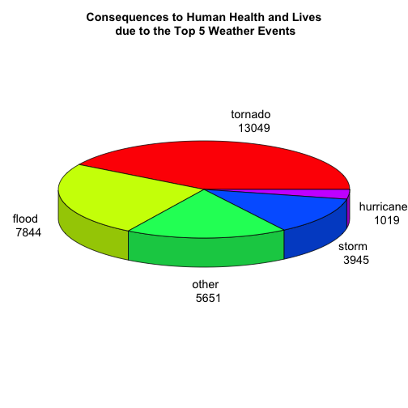

```r
X <- newData1[order(newData1$injuryFatalityTotal, decreasing=TRUE),][1:5,]
labels <- paste(X$weather, "\n", X$injuryFatalityTotal)
pie3D(X$injuryFatalityTotal, labels = labels, main="Consequences to Human Health and Lives\n due to the Top 5 Weather Events", labelcex=1.2)
```

**Based on the numbers above, the most devastating / harmful events for the human health are tornadoes, followd by floods, others, storms, and lastly, hurricanes.**  
Please note that “other” includes a variety of weather events that were not categorized into specific events due to the data analysts lack of skills in doing so.

### Across the United States, which types of events have the greatest economic consequences?

In determining the events with the greatest economic consequences, we would consider the property and crop damage data.

Pie chart of the top 5 types of event with the greatest economic consequences

Plot the 3D pie chart of the top 5 events that had the most effect on the economy in the past

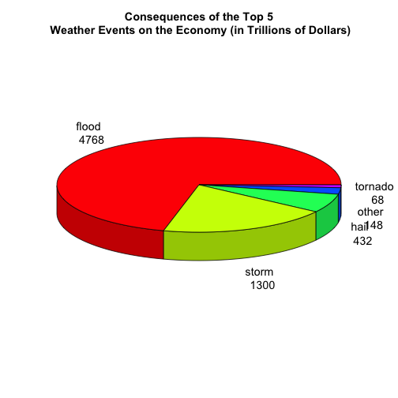

```r
Y <- newData1[order(newData1$damageTotal, decreasing=TRUE),][1:5,]
damageInTrillions <- round(Y$damageTotal/1e+12)
labels <- paste(Y$weather, "\n", damageInTrillions)
pie3D(damageInTrillions, labels = labels, main="Consequences of the Top 5\n Weather Events on the Economy (in Trillions of Dollars)", labelcex=1.2)
```

**Based on the numbers above, the most costly / economically consequential events are floods, followd by storms, hails, others, and lastly, tornadoes.**  
Please note that “other” includes a variety of weather events that were not categorized into specific events due to the data analysts lack of skills in doing so.

### (Additional analysis) Across the United States, which types of events occured the most?

Pie chart of the top 5 types of event with the highest frequency

Plot the 3D pie chart of the top 5 events that occured the most in the past

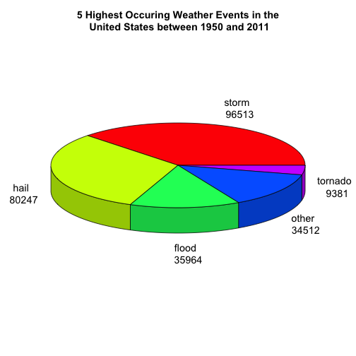

```r
Z <- newData1[order(newData1$incidentCount, decreasing=TRUE),][1:5,]
labels <- paste(Z$weather, "\n", Z$incidentCount)
pie3D(Z$incidentCount, labels = labels, main="5 Highest Occuring Weather Events in the\n United States between 1950 and 2011", labelcex=1.2)
```

**Based on the numbers above, the events that happened the most in the past are storms, followd by hails, floods, others, and lastly, tornadoes.**  
Please note that “other” includes a variety of weather events that were not categorized into specific events due to the data analysts lack of skills in doing so.